# 3PG模型概览

主讲人：杨金炎 Email: jyyoung@live.com

2022-07-04

## 1.模型简介

**P**hysiological **P**rocesses **P**redicting **G**rowth （3PG）模型首先发表于Landsberg and Warning (1997)。https://www.sciencedirect.com/science/article/pii/S0378112797000261

3PG的主要用途是根据简单的生理参数预测**森林**生产力及蒸腾。其基本原理是利用光照和光利用率计算GPP。其中光利用率受温度、湿度、土壤水分、土壤养分、树龄、二氧化碳浓度影响。

模型的主要特点有：1.完备的植物生理过程；2.科学的气候变化响应；3.动态的树木组成；4.相对简单易用。

3PG的时间尺度为月，空间尺度可以自定。模型必要的气象参数有：光照、降水、温度、湿度。模型使用的植物生理参数82个。另需林地初始状态参数54个。

使用3PG的相关研究遍布世界各地。目前已超过100篇。

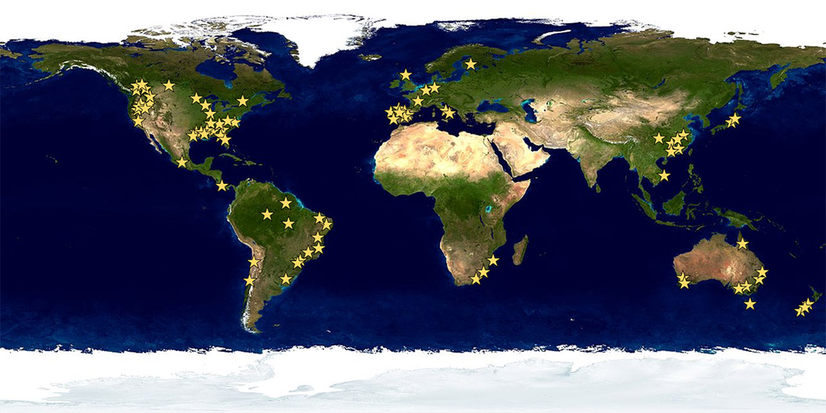

图一。使用3PG模型的研究的世界分布。

与3PG学习的相关资料很多。在本课程外，还可参阅网站 https://3pg.forestry.ubc.ca/

由于应用广泛，3PG有许多版本，涉及不同编程语言。本期课程将使用R语言中的r3PG包： https://doi.org/10.1111/2041-210X.13474

## 2.基本结构

3PG的结构与多数生态系统模型和陆面模式类似。其基本假设为植物吸收光照转化为生物量，并按一定比例用于叶、茎、根的生长。

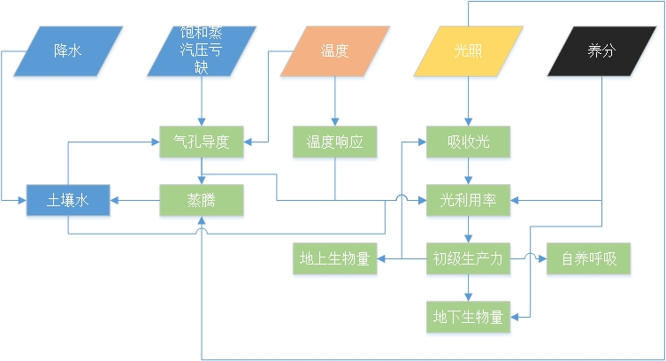

图2。简要的3PG流程图。

3PG可以分为水分利用、水胁迫、温度响应、光利用、植物生长、养分胁迫六大部分。

虽然，模型牵涉很多，各部分相互影响，但是，可以看出模型各部分的实际目的都是为了预测生产力。

## 3.运行环境

我们选用R语言https://www.r-project.org/，并用RStudiohttps://www.rstudio.com/作为操作界面。具体安装在相关网站有详细方法。在此不赘述。

简单来说R是一款为数据处理和统计专门开发的开源语言。它现有的相关功能包覆盖大多数常用编程需求。因此，R已成为最常用的科学编程语言。

我们本次只使用‘r3PG’ 相关的内容。安装方法如下：

```r
# 安装
if(require('r3PG') == FALSE){
  install.packages('r3PG')
}

# 调用
library('r3PG')
```

## 4.基本操作

### 4.1 使用帮助页面

R的基本操作之一是找到相对应的功能包和函数的帮助页面。

```r
# 功能包介绍
help(package = r3PG)
```

也可以直接查看帮助内容。

```r
# 内容列表介
ls("package:r3PG")
```

```
##  [1] "d_climate"          "d_parameters"       "d_site"
##  [4] "d_sizeDist"         "d_species"          "d_thinning"
##  [7] "get_parameters"     "i_output"           "i_parameters"
## [10] "i_parameters_lit"   "i_sizeDist"         "prepare_climate"
## [13] "prepare_input"      "prepare_parameters" "prepare_site"
## [16] "prepare_sizeDist"   "prepare_species"    "prepare_thinning"
## [19] "run_3PG"
```

### 4.2 查看数据结构

对于数据，则可查看前几行的情况以获得大致了解。也可用tail或者summary。

```r
# 内容查看-输入
head(d_climate)
```

```
##   year month    tmp_min   tmp_max   tmp_ave      prcp      srad frost_days
## 1 2001     1 -1.4669526  4.426295  1.255187 107.00000  8.406893         19
## 2 2001     2 -0.8616548  7.553571  2.982143  29.00000 12.664019         14
## 3 2001     3  3.8046124 11.463667  7.340946 195.79700 15.905757         14
## 4 2001     4  2.7947164 11.352311  6.585644 144.00001 17.775332          6
## 5 2001     5  9.7551870 20.884220 15.156178  57.20299 21.501787          0
## 6 2001     6 10.0666666 21.166666 15.428050 241.11404 18.191631          0
##       co2   d13catm
## 1 360.000 -7.677826
## 2 360.036 -7.677826
## 3 360.072 -7.677826
## 4 360.108 -7.677826
## 5 360.144 -7.677826
## 6 360.180 -7.677826
```

```r
# 内容查看-参数结构
head(i_parameters)
```

```
##   parameter                                     description unit default
## 1      pFS2        Foliage:stem partitioning ratio @ D=2 cm    -   1.000
## 2     pFS20       Foliage:stem partitioning ratio @ D=20 cm    -   0.150
## 3       aWS Constant in the stem mass v. diam. relationship    -   0.095
## 4       nWS    Power in the stem mass v. diam. relationship    -   2.400
## 5       pRx                Maximum fraction of NPP to roots    -   0.800
## 6       pRn                Minimum fraction of NPP to roots    -   0.250
```

### 4.3 查看函数功能

此处我们具体查看prepare_input这一函数的用法。此函数可以帮助我们整理输入文件格式。

```r
# 内容查看-函数
?prepare_input
```

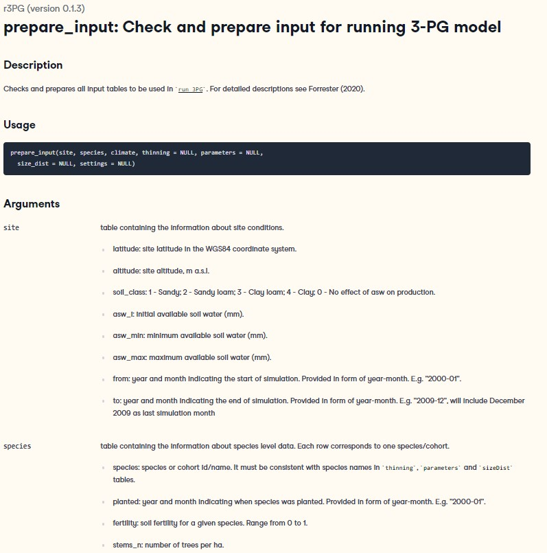

以上内容即为该函数的帮助文档。

### 4.5 模型试运行

所有参数和函数都是为了方便模型的运行。在此，我们已经可以运行3PG模型。此处的例子，是功能包自带的数据。

```r
# 运行模型
output <- run_3PG(site = d_site,#站点相关信息，初始土壤水
                  species = d_species,#树种相关信息，初始生物量
                  climate = d_climate,#气象因子
                  thinning = d_thinning,#间苗
                  parameters = d_parameters,#按树种的生理参数
                  size_dist = d_sizeDist,#修正大小分布
                  settings = list(light_model = 1,
                                  transp_model = 2, phys_model = 2,
                                  correct_bias = 0, calculate_d13c = 0),
                  check_input = TRUE, df_out = TRUE)


head(output)
```

```
##         date         species   group variable      value
## 1 2001-01-31 Fagus sylvatica climate  tmp_min -1.4669526
## 2 2001-02-28 Fagus sylvatica climate  tmp_min -0.8616548
## 3 2001-03-31 Fagus sylvatica climate  tmp_min  3.8046124
## 4 2001-04-30 Fagus sylvatica climate  tmp_min  2.7947164
## 5 2001-05-31 Fagus sylvatica climate  tmp_min  9.7551870
## 6 2001-06-30 Fagus sylvatica climate  tmp_min 10.0666666
```

我也可以查看模型具体的预测。以下是初级生产力变化实例。

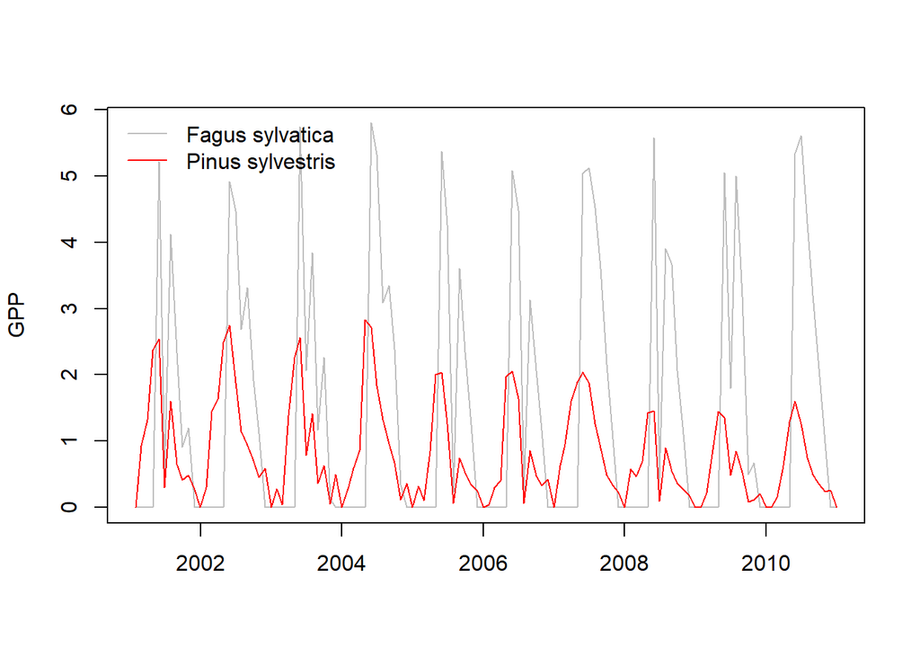

```r
# 作图
plot(value~date,data = output[output$species == 'Fagus sylvatica' &
                                output$variable == 'gpp',],
     type='l',xlab='',ylab='GPP',col='grey')

points(value~date,data = output[output$species == 'Pinus sylvestris' &
                                output$variable == 'gpp',],
     type='l',xlab='',ylab='GPP',col='red')

legend('topleft',legend = unique(output$species),
       lty='solid',col=c('grey','red'),bty='n')
```

## 5 模型输入输出

下面我们整理一下3PG所需要的输入输出数据。首先，是所需参数。

### 表1。3PG所需参数列表。

| parameter | description | unit | default |
| --- | --- | --- | --- |
| pFS2 | Foliage:stem partitioning ratio @ D=2 cm | - | 1.000 |
| pFS20 | Foliage:stem partitioning ratio @ D=20 cm | - | 0.150 |
| aWS | Constant in the stem mass v. diam. relationship | - | 0.095 |
| nWS | Power in the stem mass v. diam. relationship | - | 2.400 |
| pRx | Maximum fraction of NPP to roots | - | 0.800 |
| pRn | Minimum fraction of NPP to roots | - | 0.250 |
| gammaF1 | Maximum litterfall rate | 1/month | 0.027 |
| gammaF0 | Litterfall rate at t = 0 | 1/month | 0.001 |
| tgammaF | Age at which litterfall rate has median value | months | 12.000 |
| gammaR | Average monthly root turnover rate | 1/month | 0.015 |
| leafgrow | If deciduous, leaves are produced at end of this month | month | 0.000 |
| leaffall | If deciduous, leaves all fall at start of this month | month | 0.000 |
| Tmin | Minimum temperature for growth | deg. C | 8.500 |
| Topt | Optimum temperature for growth | deg. C | 16.000 |
| Tmax | Maximum temperature for growth | deg. C | 40.000 |
| kF | Days production lost per frost day | days | 0.000 |
| SWconst | Moisture ratio deficit for fq = 0.5 | - | 0.700 |
| SWpower | Power of moisture ratio deficit | - | 9.000 |
| fCalpha700 | Assimilation enhancement factor at 700 ppm | - | 1.400 |
| fCg700 | Canopy conductance enhancement factor at 700 ppm | - | 0.700 |
| m0 | Value of ‘m’ when FR = 0 | - | 0.000 |
| fN0 | Value of ‘fNutr’ when FR = 0 | - | 1.000 |
| fNn | Power of (1-FR) in ‘fNutr’ | - | 0.000 |
| MaxAge | Maximum stand age used in age modifier | years | 50.000 |
| nAge | Power of relative age in function for fAge | - | 4.000 |
| rAge | Relative age to give fAge = 0.5 | - | 0.950 |
| gammaN1 | Mortality rate for large t | %/year | 0.000 |
| gammaN0 | Seedling mortality rate (t = 0) | %/year | 0.000 |
| tgammaN | Age at which mortality rate has median value | years | 0.000 |
| ngammaN | Shape of mortality response | - | 1.000 |

[output cut: 52 more lines]

### 表2。3PG所需气象数据列表。

| Variable | Discription | Unit |
| --- | --- | --- |
| year | year | - |
| month | month | - |
| tmp_min | monthly mean daily minimum temperature | Celsius |
| tmp_max | monthly mean daily maximum temperature | Celsius |
| prcp | monthly rainfall | mm month-1 |
| srad | monthly mean daily solar radiation | MJ m-2 d-1 |
| frost_days | frost days per month | day |
| co2 | monthly mean atmospheric co2 | p.p.m |

### 表3。3PG所需站点数据列表。

| Variable | Discription | Unit |
| --- | --- | --- |
| latitude |  | - |
| altitude |  | - |
| soil_class | 1 - Sandy; 2 - Sandy loam; 3 - Clay loam; 4 - Clay; 0 - No effect | - |
| asw_i | initial available soil water | mm |
| asw_min | minimum available soil water | mm |
| asw_max | maximum available soil water | mm |
| from | start of simulation | mm |
| to | end of simulation | YYYY-mm |

### 表4。3PG植物及初始信息数据列表。

| Variable | Discription | Unit |
| --- | --- | --- |
| species |  | - |
| planted | year and month indicating when species was planted | - |
| fertility | soil fertility for a given species | 0-1 |
| stems_n | number of trees per ha | No./ha |
| biom_stem | stem biomass for a given species | Mg/ha |
| biom_root | root biomass for a given species | Mg/ha |
| biom_foliage | initial foliage biomass | Mg/ha |

### 表5。3PG植物自然稀疏信息列表。

| Variable | Discription |
| --- | --- |
| species |  |
| age | age when thinning is performed |
| stems_n | number of trees per ha after thinning |
| stem | type of thinning (above/below) |
| root | type of thinning (above/below) |
| foliage | type of thinning (above/below) |

### 表6。3PG输出信息列表。

| group_id | variable_id | variable_name | variable_group | description | unit | variable_vba |
| --- | --- | --- | --- | --- | --- | --- |
| 1 | 1 | tmp_min | climate | Minimum daily temperature | C | Min temp. |
| 1 | 2 | tmp_max | climate | Maximum daily temperature | C | Max temp. |
| 1 | 3 | tmp_ave | climate | Mean daily temperature | C | Mean temp. |
| 1 | 4 | frost_days | climate | Number of frost days per month | d month-1 | Frost days |
| 1 | 5 | solar_rad | climate | Mean daily incident solar radiation | MJ m-2 d-1 | Solar rad. |
| 1 | 6 | day_length | climate | Day length (sunrise to sunset) | s d-1 | Daylength |
| 1 | 7 | prcp | climate | Monthly precipitation sum | mm month-1 | Rainfall |
| 1 | 8 | vpd_day | climate | Mean day-time VPD | mbar | VPD |
| 1 | 9 | co2 | climate | Atmospheric CO2 | ppm | CO2 |
| 1 | 10 | delta13c | climate | Delta 13C of the atmosphere | NA | atm delta 13C |
| 1 | 11 | var_1_11 | climate | Applied irrigation | mm month-1 | Applied irrig. |
| 1 | 12 | var_1_12 | climate | NA | NA | NA |
| 1 | 13 | var_1_13 | climate | NA | NA | NA |
| 1 | 14 | var_1_14 | climate | NA | NA | NA |
| 1 | 15 | var_1_15 | climate | NA | NA | NA |
| 2 | 1 | age | stand | Species age | years | Age species |
| 2 | 2 | stems_n | stand | Stand stocking | trees ha-1 | Stems |
| 2 | 3 | basal_area | stand | Stand basal area | m2 ha-1 | Basal area |
| 2 | 4 | basal_area_prop | stand | Proportion of stand basal area (totalBA) contributed by the given species species | % | SpeciesProportionBA |
| 2 | 5 | dbh | stand | Mean DBH | cm | Mean DBH |
| 2 | 6 | height | stand | Mean height | m | Height |
| 2 | 7 | height_rel | stand | Height of the given species divided by the mean height of all trees in the stand (e.g. mean height of all species weighted by the number of trees per ha of that species) | - | SpeciesProportionLAI |
| 2 | 8 | crown_length | stand | Mean live-crown length | m | LCL |
| 2 | 9 | crown_width | stand | Mean crown diameter | m | crowndiameter |
| 2 | 10 | volume | stand | Stand volume excluding branch & bark | m3 ha-1 | Stand volume |
| 2 | 11 | volume_mai | stand | Mean annual volume increment | m3 ha-1 yr-1 | MAI |
| 2 | 12 | volume_change | stand | Stem volume increment in current period | m3 ha-1 | CVI |
| 2 | 13 | volume_cum | stand | Total cumulative volume (stand volume + extracted volume + mortality) | m3 ha-1 | Total cumulative volume |
| 2 | 14 | var_2_14 | stand | NA | NA | NA |
| 2 | 15 | var_2_15 | stand | NA | NA | NA |

[output cut: 120 more lines]

## 6.功能模块-生产力计算

### 6.1 光利用-生产力

在3PG中，初级生产力直接有多个环境变量及胜利参数计算得出。
$$GPP = Qf_l(L) \alpha f_t(T)f_w(W)f_g(g_s)~~~~~~~~(1)$$

### 6.2 光照

光照强度有多种度量方式。注意3PG需要的是月日均光照（monthly mean daily solar radiation），单位是$MJ~m^{-2}~d^{-1}$。因为模型实际需要月尺度数据，实际模型在计算时，会先换算成月总光照。

### 6.3 叶面积指数

光照首先受到现有植被叶面积指数（L）的影响：
$$f_l = (1-e^{-kL})~~~~~~~~(2)$$
这一关系由Beer–Lambert定律支持。此处，一般假设k=0.5。

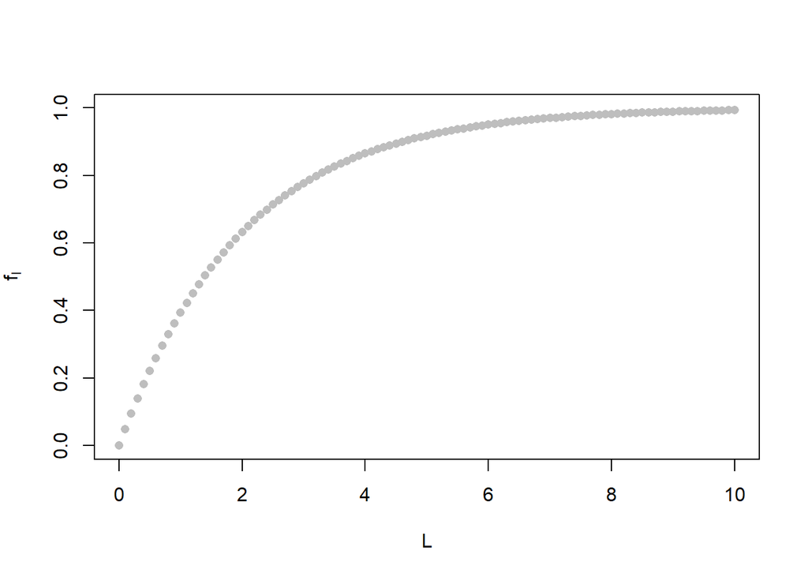

```r
# 生产力与光照
lai.vec <- seq(0,10,by=0.1)
plot.df <- data.frame(lai = lai.vec,
                      f.low = 1-exp(-0.5*lai.vec))

plot(f.low~lai,data = plot.df,
     type='p',pch=16,xlab='L',ylab=expression(f[l]),col='grey',
     ylim=c(0,1))
```

一般情况下，这一方程不需要调整参数。但是，叶面积指数受到比叶面积（SLA）影响。因此，要特别注意比叶面积数值。

以上是3PG的最根本性假设，至此我们已经可以计算初级生产力：

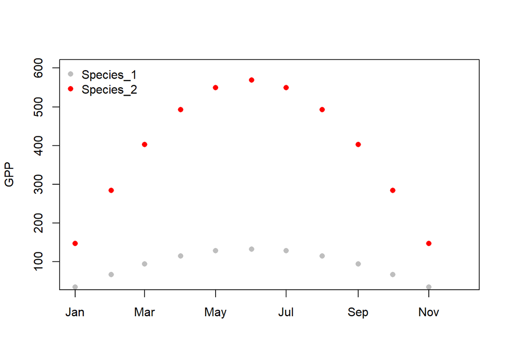

```r
# 生产力计算
# 参数
par.dummy.df <- data.frame(species = c('x1','x2'),
                      lai = c(0.5,2),
                      alpha = c(2,3))
# 光照
met.dummy.df <- data.frame(date = seq(as.Date('2000-1-1'),
                                      as.Date('2000-12-31'),by='month'),
                           solar = 10*sin((1:12)/12*pi))
# 日均换算月均
dayInMonth = 30
# 计算GPP
met.dummy.df$gpp.x1 <- par.dummy.df$alpha[par.dummy.df$species=='x1']*
  (1-exp(-0.5*par.dummy.df$lai[par.dummy.df$species=='x1']))*
  met.dummy.df$solar * dayInMonth

met.dummy.df$gpp.x2 <- par.dummy.df$alpha[par.dummy.df$species=='x2']*
  (1-exp(-0.5*par.dummy.df$lai[par.dummy.df$species=='x2']))*
  met.dummy.df$solar * dayInMonth
# 作图
plot(gpp.x1~date,data = met.dummy.df,
     type='p',pch=16,xlab=' ',ylab='GPP',col='grey',
     ylim=c(50,600))
points(gpp.x2~date,data = met.dummy.df,
     type='p',pch=16,ylab=expression(f[l]),col='red')

legend('topleft',legend = c('Species_1','Species_2'),
       pch=16,col=c('grey','red'),bty='n')
```

### 6.4 光能利用率

光能利用率（$\alpha$）是基于不同物种的重要参数。它的基本意义是每单位太阳辐射对应的碳吸收（$g~MJ^{-1}$）。$\alpha$的重要性体现在它代表了生产力对于光照的线性关系。

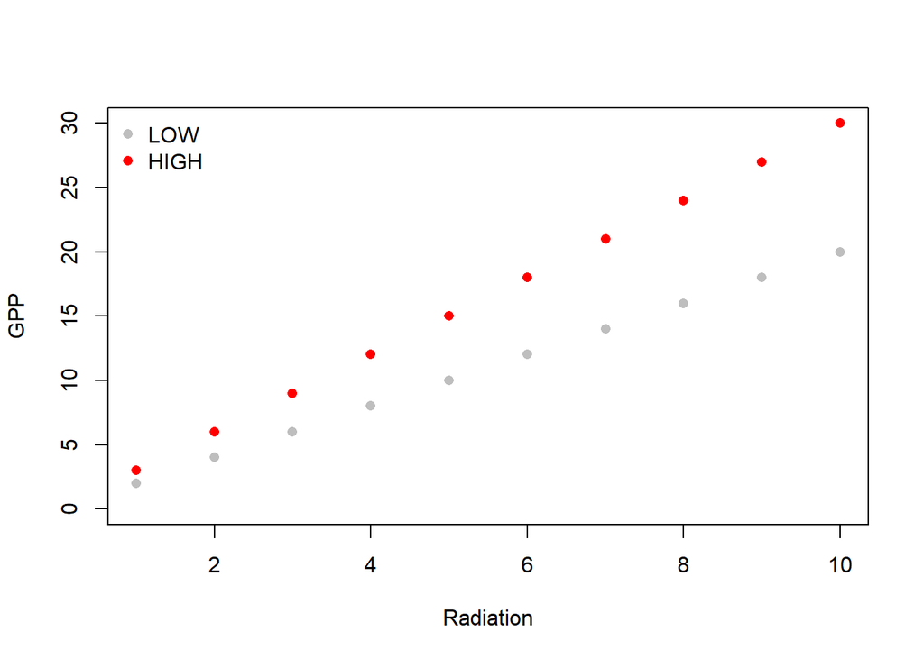

```r
# 生产力与光照
plot.df <- data.frame(q = 1:10,
                      GPP.low = (1:10) * 2,
                      GPP.high = (1:10) * 3)

plot(GPP.low~q,data = plot.df,
     type='p',pch=16,xlab='Radiation',ylab='GPP',col='grey',
     ylim=c(0,30))

points(GPP.high~q,data = plot.df,
     type='p',pch=16,xlab='',col='red')

legend('topleft',legend = c('LOW','HIGH'),
       pch=16,col=c('grey','red'),bty='n')
```

### 6.5 温度

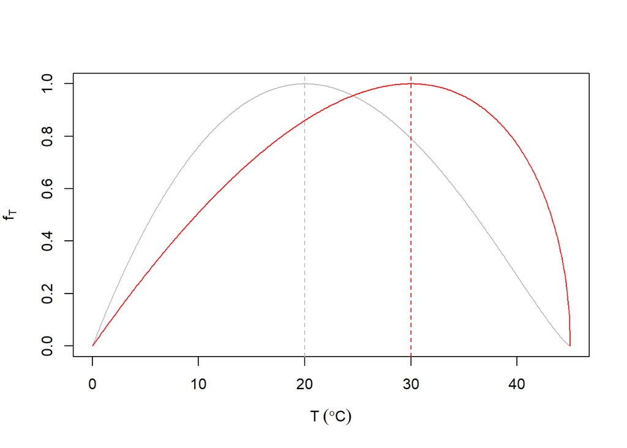

```r
# 温度
tmin= 0
tmax=45
t.vec <- seq(tmin,tmax,by=0.1)
# 计算
t.func <- function(t.vec,t.opt,t.max,t.min){
  (t.vec - t.min) / (t.opt - t.min) *
    ((t.max-t.vec) / (t.max-t.opt))^((t.max-t.opt)/(t.opt - t.min))
}

ft20 <- t.func(t.vec,t.opt = 20,t.max = tmax,t.min = tmin)
ft30 <- t.func(t.vec,t.opt = 30,t.max = tmax,t.min = tmin)

plot(ft20~t.vec,
     type='l',xlab=expression(T~(degree*C)),
     ylab=expression(f[T]),col='grey',
     ylim=c(0,1))

points(ft30~t.vec,
     type='l',pch=16,xlab='',col='red')
abline(v=20,col='grey',lty='dashed')
abline(v=30,col='red',lty='dashed')
```

### 6.6 土壤水

土壤含水量对于光利用率的影响与土壤类型有关。具体参见Lansberg and Warning （1997）:

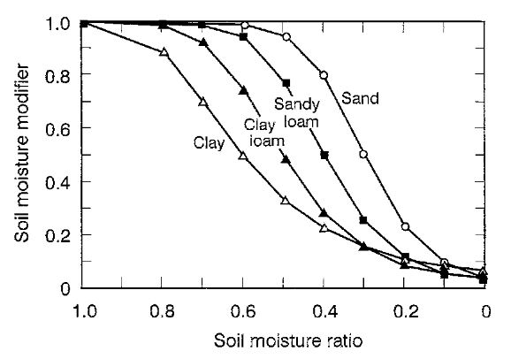

### 6.7 气孔导度

不同于很多其他基于Farquhar模型的日尺度模型，3PG的气孔导度是直接由饱和蒸气压亏缺（D; kPa）计算的出的。

$$g_{s} =
g_{s.max}e^{1-k_{g}D}~~~~~~~~(4)$$

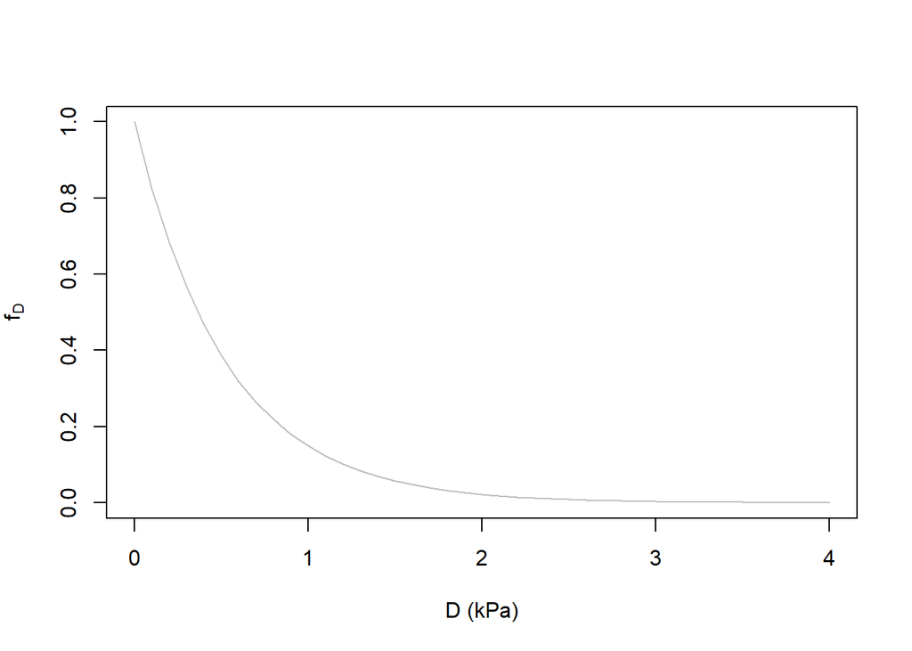

```r
# VPD
gmax1= 0.1
vpd.vec <- seq(0,4,by=0.1)

# 计算
vpd.func <- function(vpd,gmax,k = 1.9){
  exp(-1.9*vpd)
}

f.g.1 <- vpd.func(vpd.vec,gmax = gmax1)

plot(f.g.1~vpd.vec,
     type='l',xlab=('D (kPa)'),
     ylab=expression(f[D]),col='grey',
     ylim=c(0,1))
```

```r
# 运行模型
par.df <- get_parameters(mode = 'full',sp_names = 'Eucalyptus globulus')
par.df <- subset(par.df,select = -c(parset_id,age,type,year,region,
                                    country,notes,source,source_comments,
                                    source_full,link))
library(doBy)
par.df.sum <- summaryBy(.~species ,data = par.df,
                        FUN=mean,na.rm=T,keep.names=T)

long.df <- as.data.frame(t(subset(par.df.sum,select = -species)))
names(long.df) <- 'Eucalyptus globulus'
```

### 6.8 霜冻、树龄及土壤养分

3PG可以计算霜冻、树龄和养分不足造成的生长下降。其计算方式十分简单。对于霜冻，即在发生霜冻的时间按固定比例减少初级生产力。树龄则同样使生产力非线性下降。而营养不足除了按比例减少初级生产力，还会改变植物生物量分配。这些关系较为简单且使用时改变较小，故不作深入讨论。

### 6.9 二氧化碳响应

与其他响应类似，3PG的二氧化碳响应也是由响应方程定义。其中，首要的参数是二氧化碳的促进参数：

$$f_{c}=\frac{f_{Calpha700}}
{(2-f_{Calpha700})} ~~~~~~~~(5)$$

这一变化率直接用于计算光利用率的变化：

$$f_{alpha,CO_{2}}=\frac{f_{c} CO_{2}}
{(350(f_{c}-1)+CO_{2}} ~~~~~~~~(6)$$

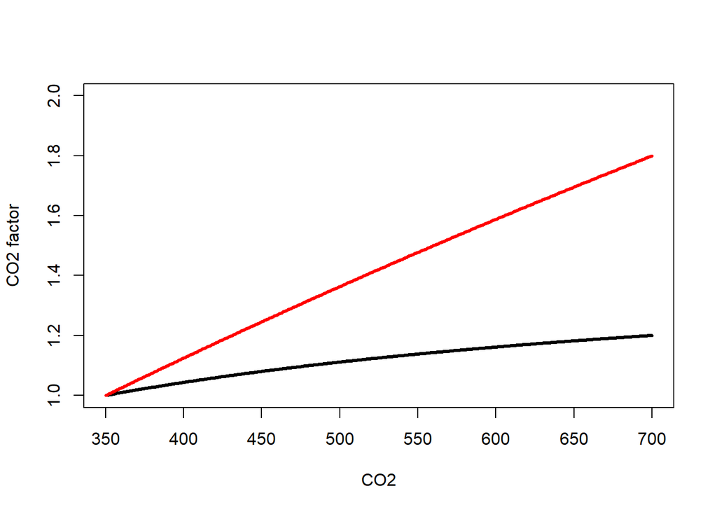

```r
plot.co2.response.func <- function(fc.700 = 1.8,add.plot=FALSE){
  co2 <- seq(350,700)
fC = fc.700 / (2 - fc.700)
falpha = fC * co2 / (350* (fC - 1) + co2)
if(add.plot){
  points(falpha~co2,type='l',col='red',lwd=3)
}else{
  plot(falpha~co2,xlab='CO2',ylab='CO2 factor',type='l',ylim=c(1,2),lwd=3)
}

}
plot.co2.response.func(fc.700 = 1.2)
plot.co2.response.func(fc.700 = 1.8,add.plot = T)
```

## 7.功能模块-水分利用及植物生长

### 7.1 从降水到蒸腾

3PG假设土壤水均匀分布在给定深度内。降水先经过冠层截留，剩余部分全部进入土壤中。

土壤中的水分有两种流失途径：蒸腾和蒸发。这两种途径都是通过Penman-Monteith 方程计算，仅是参数不同。

这一简化的PM方程结构如下：

$$E= \frac{g_{c}}{\lambda} \frac{e_{20}
R_{net} + \rho_{air} \lambda / r_{aero} }{g_{c}(1+e_{20}) + 1/r_{aero}}
d_{length}~~~~~~~~(5)$$
此处，E是蒸腾或者蒸发的能量，单位是$kg~m^{-2}h^{-1}$ 顾需要考虑每月日数转化为月总量。$g_{c}$ 是冠层导度（$kg~m^{-2}h^{-1}$），注意对于蒸发则使用土壤导度。两者计算方式不同。$\lambda$是水汽化热（2460000$J~kg^{-1}$）。$e_{20}$是简化的饱和蒸气压对温度的斜率（2.2$kPa~ ^\circ C^{-1}$）。$R_{net}$是净辐射能量（$MJ~m^{-2}~h^{-1}$）。$R_{net}$计算较为复杂，此处简化为总辐射乘以$f_l$。$\rho_{air}$是空气密度（1.2$kg~m^{-3}$）。$r_{aero}$是空气阻力（$h~kg^{-1}$），即界面层导度的倒数。$d_{length}$是每日小时数。

对于多树种混杂的情况，则按照每种树的L分别计算蒸腾。而蒸发则是不考虑树种而是用L之和。

**若某月蒸散失大于土壤水分和降水之和，则假定所有可用水分即为蒸散失的实际值。并按照实际和计算值的比例减少初级生产力。**

### 7.2 植物生长

3PG以根生长为优先。每月新增生物量的实际分配在给定的最大和最小根配机率之间，由每种树给定的土壤养分比例（0-1）决定。剩余生物量按比例分配给茎生长。最后剩余部分全部用于叶生长。根茎叶各有独立的凋亡比例。每月生长和凋亡的净值决定了实际生物量变化。

叶面积指数L为叶生物量与比叶面积之积。

## 8.相关文献

案例

Trotsiuk et al., 2020. Assessing the response of forest productivity to climate extremes in Switzerland using model–data fusion, GCB. https://doi.org/10.1111/gcb.15011

模型

Landsberg, J. J., & Waring, R. H., 1997. A generalised model of forest productivity using simplified concepts of radiation-use efficiency, carbon balance and partitioning. Forest Ecology and Management, 95(3), 209–228. doi: 10.1016/S0378-1127(97)00026-1

使用手册

Sands, P. J., 2010. 3PGpjs user manual. Available at the following web site: https://3pg.sites.olt.ubc.ca/files/2014/04/3PGpjs_UserManual.pdf